# presentation

10/8/2021

## “United States” versus “Japan” (life expectancy)

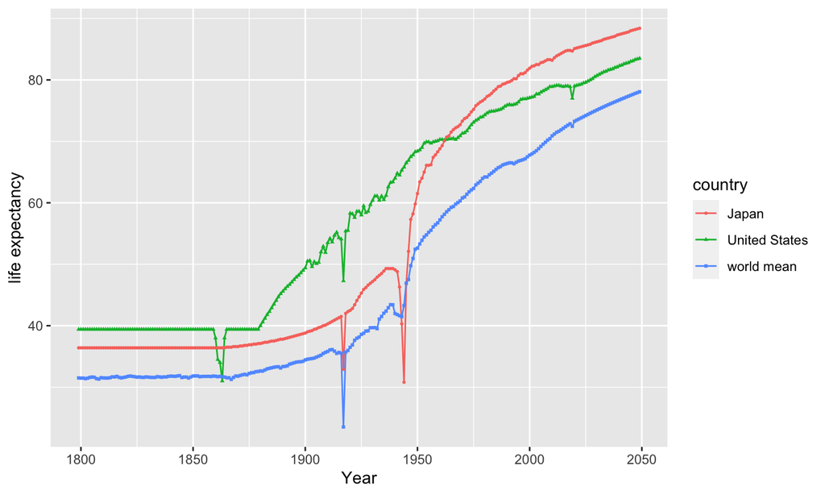

## “United States” versus “Japan” (income per person ($))

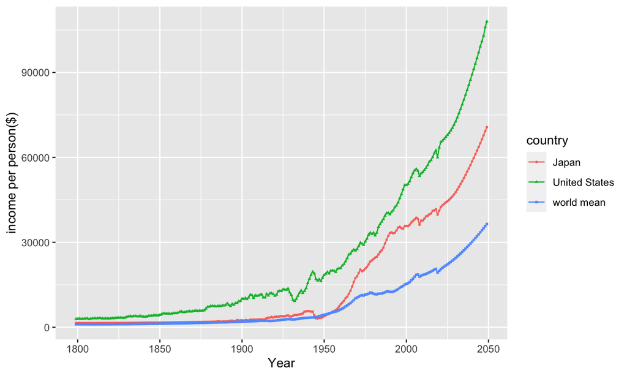

## Intro to the plot

Take a look at the first plot, where x-axis is year index and y-axis is life expectancy. In the plot, the red line represent Japan, green line represents United States and blue line represents world average life expectancy. On the whole, life expectancies of both two countries and world average have grown from under 40 to approximately 80. Additionaly, as developed countries, both United States and Japan’ life expectancies are higher than world average.